# 完全2次元名義カテゴリカル分析 Scientific Dashboard

Interface 3.0 (two-way-results-v2) | Run ID: `theme_cat_demo` | 生成日時: `2026-09-28T02:57:02+09:00`

## 2. 全体連関構造 (Global Association & Effect Size)

総標本サイズ ($N$)

100

分割表次元: 2 × 2 ($df = 1$)

Pearson $X^2$ (独立性検定統計量)

16.67

$p$ 値: 4.46e-05

Cramér’s $V$ (未補正)

0.4082

95% CI: [0.2123, 0.6042]

偏り補正 Cramér’s $\tilde{V}$ (Bergsma)

0.3977

95% CI: [0.2133, 0.6073]

## 3. 局所効果 × 証拠散布図 (Effect × Evidence & Dual-Filter)

局所対数効果比 $\log(O/E)$ と局所 Rao スコア検定統計量 $T^{\mathrm{score}}$ による2軸診断。 大標本（$N \ge 2000$）では $|\log(O/E)| \ge 0.50$ かつ $T^{\mathrm{score}} \ge 3.84$ を満たす非隔離セルを注目候補として抽出します。

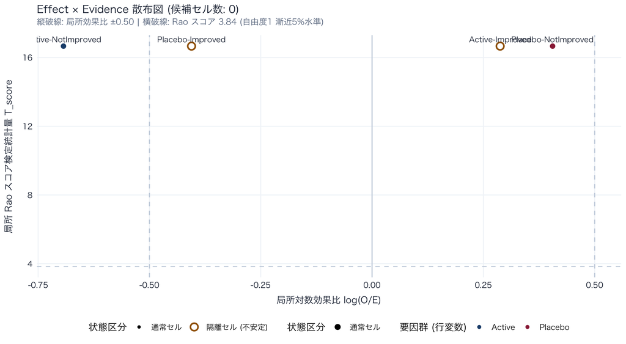

## 4. 調整標準化残差ヒートマップ (Adjusted Standardized Residual Heatmap)

**統計的・科学的問い:** 独立モデル（行と列が無関連）を仮定したとき、各セルの観測度数は期待度数から統計的にどの程度逸脱しているか（標準化残差）？

※ **解釈上の注意:** 調整標準化残差（Haberman の $z_{ij}$）は、独立モデルからの局所的な統計的乖離を示す探索指標であり、**効果の大きさや実務的重要性そのものではありません**。±1.96および±2.58は多重性を調整していない名目上の探索目安です。期待度数、Leverage、ゼロ観測、小期待度数、Quarantine状態、Section 3 の局所対数効果比 $\log(O/E)$ を併せて評価してください。

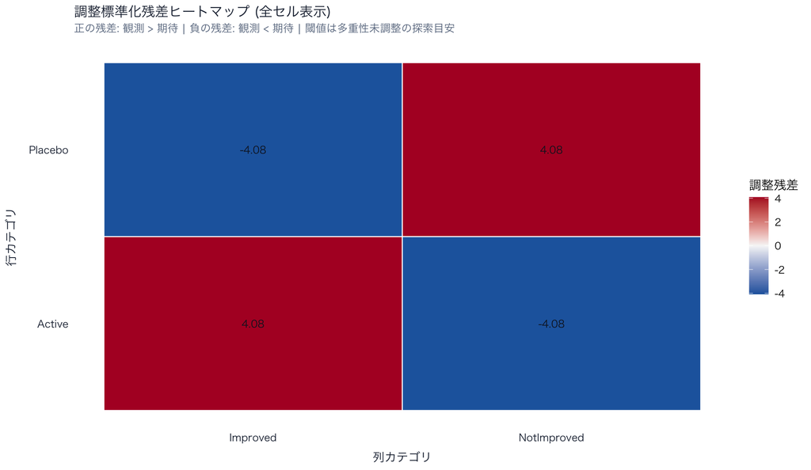

## 5. セル診断エクスプローラー (Cell Explorer)

| 行 | 列 | 観測度数 | 期待度数 | Pearson残差 | 調整残差 | レバレッジ | log(O/E) | Raoスコア | p値(BH) | 状態 | 候補 |
| --- | --- | --- | --- | --- | --- | --- | --- | --- | --- | --- | --- |
| Active | Improved | 40 | 30 | 1.8257 | 4.0825 | 0.8 | 0.2877 | 16.6667 | 0.0000 | QUARANTINED | - |
| Active | NotImproved | 10 | 20 | -2.2361 | -4.0825 | 0.7 | -0.6931 | 16.6667 | 0.0000 | ACTIVE | - |
| Placebo | Improved | 20 | 30 | -1.8257 | -4.0825 | 0.8 | -0.4055 | 16.6667 | 0.0000 | QUARANTINED | - |
| Placebo | NotImproved | 30 | 20 | 2.2361 | 4.0825 | 0.7 | 0.4055 | 16.6667 | 0.0000 | ACTIVE | - |

## 6. 結合事後推論 (Joint Posterior Credible Intervals)

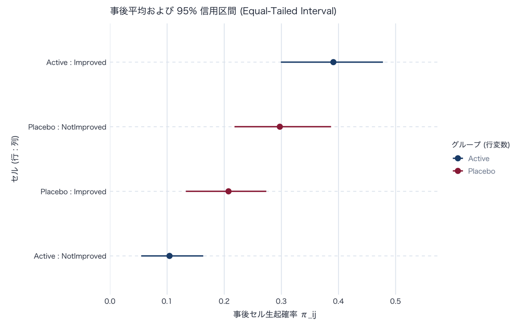

## 7. 条件付き事後推論 (Conditional Posterior Distributions)

**統計的・科学的問い:** 行カテゴリ $A=i$ が観測された条件のもとで列カテゴリ $B=j$ が生起する予測確率 $P(B=j\mid A=i)$、および列カテゴリ $B=j$ が観測された条件のもとで行カテゴリ $A=i$ が生起する予測確率 $P(A=i\mid B=j)$ はどの程度か？

※ **解釈上の注意:** 条件付き事後確率は行または列を条件づけた予測確率を表します。主表示は中央値および 95% 等裾信用区間（ETI: [Q2.5, Q97.5]）であり、平均値は補助指標（点）として表示しています。次の1観測の予測確率は対応する条件付き確率の事後平均であり、中央値ではありません。**中央値や分位点の総和は一般には 1 に制約されません**（2カテゴリの連続分布では中央値が補数となり和が 1 となる場合があります。総和が厳密に 1 となるのは各モンテカルロドローおよび事後平均です）。中央値の総和が 1 でないことをもって計算の誤りと誤認しないでください。

### 7.1 行条件付き事後予測確率 $P(B=j\mid A=i)$

行カテゴリ $A$ を所与としたときの列カテゴリ $B$ の事後生起確率分布（行方向の予測プロファイル）。

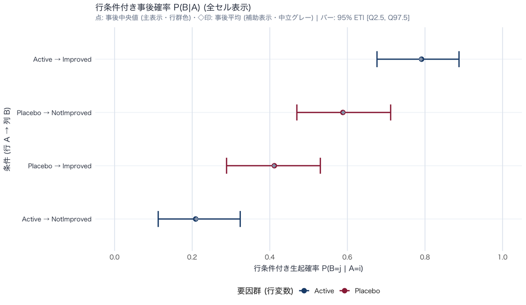

### 7.2 列条件付き事後予測確率 $P(A=i\mid B=j)$

列カテゴリ $B$ を所与としたときの行カテゴリ $A$ の事後生起確率分布（列方向の予測プロファイル）。

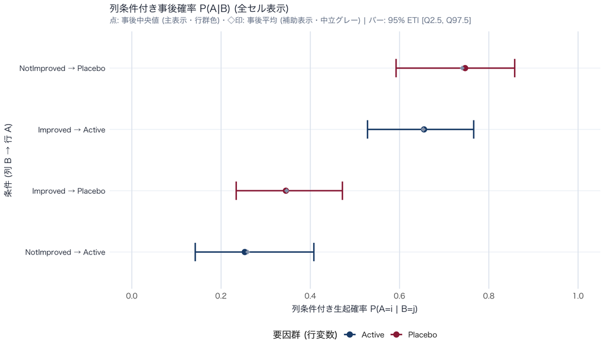

## 8. 不確実性順位 (Uncertainty Ranking)

**統計的・科学的問い:** 各セルの結合生起確率の推定における不確実性（95% 等裾信用区間幅: prob_eti_width）はどの程度か？ どのセルの推定精度が相対的に高く／低いか？

※ **解釈上の注意:** 信用区間幅（`prob_eti_width`）は生起確率推定の不確実性の大きさ（情報量の多寡）を示す指標であり、**セルの重要性または統計的有意性を示すものではありません**。観測度数が小さいセルや比率が 0.5 に近いセルでは不確実性幅が広くなる傾向がありますが、不確実性の大小をもって効果の有無や優先順位を機械的に二値判定しないでください。順位は既存の `rank` 昇順をそのまま使用しています。

[figure not shown]

## 9. 独立モデルからの事後乖離 (Posterior Departure from Independence)

**統計的・科学的問い:** 独立モデル（行と列が無関連）を仮定したときの期待確率から、各セルの事後結合確率はどの程度乖離（log divergence）しているか？

※ **解釈上の注意:** 対数乖離（Log Divergence: $\log(p_{ij} / (p_{i\cdot} p_{\cdot j}))$）は、独立モデル予測に対するセルの相対的な増減（正: 過剰、負: 過少）を表します。主指標は事後中央値および 95% 等裾信用区間（ETI）です。**対数乖離の信用区間が 0（独立基準線）をまたぐか否かだけで自動二値判定（有意／非有意の二値分類）を行わないでください**。乖離の大きさ、区間幅の不確実性、実務的意味を総合的に考慮してください。

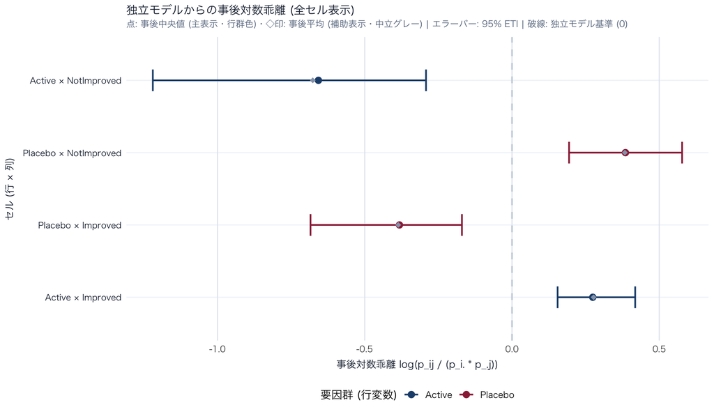

## 10. 事前感度分析 (Prior Sensitivity Analysis)

**統計的・科学的問い:** 主解析の無情報事前分布（Jeffreys事前 $\alpha=0.5$）から感度解析の一様事前分布（$\alpha=1.0$）へ事前パラメータを変更した際、事後推論結果はどの程度影響を受けるか（頑健性）？

※ **解釈上の注意:** 事後中央値シフト量（`median_shift`）および信用区間幅差（`eti_width_difference`）は、事前分布の選定に対する事後分布の頑健性を確認するための診断指標です。**$\alpha=1.0$ と $\alpha=0.5$ の差が存在することをもってモデル誤りや解析の欠陥と自動判定しないでください**。標本サイズが小さいセルほど事前分布の感度が高くなる傾向があります。

主解析事前分布 (Primary)

Jeffreys (α = 0.5)

主解析 Dirichlet パラメータ

感度解析事前分布 (Sensitivity)

Uniform (α = 1)

比較用一様 Dirichlet パラメータ

最大中央値シフト量

0.0094

max(|median_primary - median_sens|)

最大ETI幅差

0.0186

max(|ETI_sens - ETI_primary|)

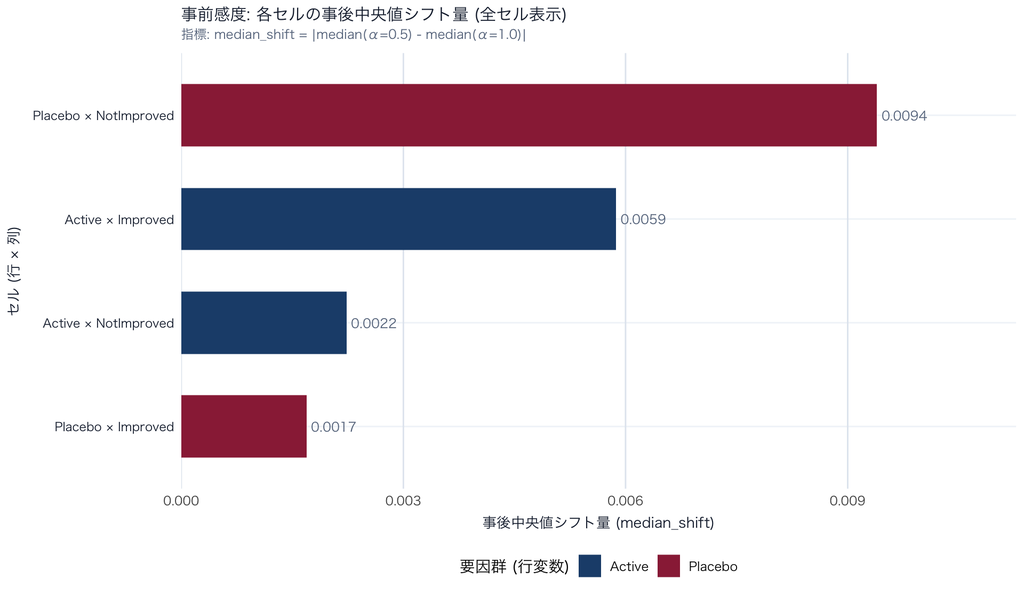

## 11. 品質・プロビナンス情報 (Quality & Provenance)

**統計的・科学的問い:** 本解析の実行パラメータ、Pass 0承認入力との整合性、および再現性監査情報は保証されているか？

実行モード (Execution Mode)

`canonical`

モード境界: Canonical Core 封緘

Pass 0 三者SHA検証状態

未確認

入力データ・設定・検査SHAの三者照合

決定論的乱数シード

`70777853`

署名ハッシュ導出・完全再現可能

Monte Carlo ドロー数

200

Dirichlet事後推論サンプリング数

[output not shown]

#### 品質警告事項

- 検出された 2 個の隔離セル（ゼロ度数/期待度数<5/高レバレッジ）を大標本Dual-Filter候補から除外しました。

実行プラットフォーム: aarch64-apple-darwin23 / R version 4.6.1 (2026-06-24) | Rバージョン: R version 4.6.1 (2026-06-24) | タイムスタンプ(JST): 2026-09-28T02:57:02+09:00

## Appendix — 統計用語集・方法論解説・学術リファレンス (Glossary & Scientific References)

統計的・科学的問い:

本ダッシュボードで使用されている統計指標、診断アルゴリズム、および数理モデルの定義・解釈境界および学術的出典は何か？

**3大利用原則:** ① P値単独判定の排除（全体検定の有意差のみで実務的重要性や個別セルを判定しない） / ② 局所効果（Effect）と統計的証拠（Evidence）を分けて読む（標本数が増えると、小さな差にも強い証拠が得られる場合があります） / ③ 不確実性の明示（点推定と等裾信用区間を併せて精度を評価）

※ 各項目をクリックして開閉できます。臨床・疫学およびリアルワールドデータ分析におけるエビデンス解釈の拠り所としてご活用ください。

**1. 全体連関・効果量 (Global Association & Effect Size) ── [対応: Section 2]**

Pearson X² 独立性検定統計量

行変数と列変数の相互独立帰無仮説 (H0: π<sub>ij</sub> = π<sub>i+</sub> π<sub>+j</sub>) のもとで算出される漸近カイ二乗統計量 X<sup>2</sup> = Σ (O<sub>ij</sub> − E<sub>ij</sub>)<sup>2</sup> / E<sub>ij</sub>（自由度 (I−1)(J−1)）。

**どこを見るか:** Section 2（全体連関構造と効果量）**誤解しないこと:** 大標本下では微小な差異でも X<sup>2</sup> が極大化し P 値が飽和するため、臨床的・実務的効果の大きさを測る指標としては用いません。

Cramér’s V

分割表全体の連関度合いを 0〜1 で標準化した効果量指標 V = √((X<sup>2</sup> / N) / min(I−1, J−1))。

**どこを見るか:** Section 2（全体連関構造と効果量）**誤解しないこと:** 標本サイズ N が有限のとき上方にバイアス（過大評価傾向）を持ちます。

偏り補正 Cramér’s Ṽ (Bergsma 2013)

有限標本における自由度と標本サイズに基づく漸近バイアス低減量。

**どこを見るか:** Section 2（全体連関構造と効果量）（95% CI と併記）**誤解しないこと:** 有限標本バイアスの低減量であり、厳密な意味での最小分散「不偏推定量」ではありません。

**2. 局所セル診断と 4 軸フレームワーク (Four-Axis Local Cell Diagnostics) ── [対応: Sections 3–5]**

【第1軸】Effect (局所対数効果比: log(O/E))

基準モデルの期待度数 E に対する観測度数 O の局所対数効果比 λ = log(O/E)。これは倍率そのものではなく倍率の自然対数です。同じ度数構成を c 倍し、同一モデルを再適合した場合に Effect は不変です。

**どこを見るか:** Section 3（横軸: Effect）、Section 9（事後乖離）**誤解しないこと:** 因果効果ではありません。 2次元JSONでは O = 0 かつ E > 0 の log(O/E) は −∞ という非有限状態として別途表現します。 一般の追加標本や帰無仮説のもとで常に N 比例と断定しません。

【第2軸】Evidence (Leverage補正Score統計量 T_score / 対数P値)

レバレッジ補正スコア z = (O − E) / sqrt(E(1 − h))、T<sub>score</sub> = z<sup>2</sup>。同じ構成比で度数を c 倍し同一モデルを再適合すると、その条件で T<sub>score</sub> は c 倍です。

**どこを見るか:** Section 3（縦軸: Evidence）**誤解しないこと:** 正規／χ<sup>2</sup> 近似には帰無仮説と適切な漸近条件が必要です。h = 1 等の退化では有限な通常式を主張しません。実務的重要性を単独で証明しません。

【第3軸】Influence (レバレッジ h_ii)

2次元独立モデルでは閉形式 h<sub>ij</sub> = p<sub>i+</sub> + p<sub>+j</sub> − p<sub>i+</sub> p<sub>+j</sub> です。当該セルが分割表全体のパラメータ推定に与える潜在的な影響（てこ比）を示します。

**どこを見るか:** Section 5（Cell Explorer 表）**誤解しないこと:** 積項の係数は −1 です（−2 ではありません）。高レバレッジは潜在的影響であり、実際の削除影響量そのものではありません。モデル異常やデータ誤りと同一視しません。

【第4軸】Stability (隔離条件 QUARANTINED)

運用上の隔離条件: ① 観測度数 O = 0、② 期待度数 E < 5.0、③ 高レバレッジ h ≥ 0.80 のいずれか。

**どこを見るか:** Section 3（中空丸プロット）、Section 4・5**誤解しないこと:** E < 5 や h ≥ 0.80 は運用上の隔離条件であり、近似精度を保証する定理ではありません。第三の臨床群や削除すべき不正データではありません。

大標本 Dual-Filter 原則

探索的候補抽出です。FWER / FDR は保証しません。現行の候補規約: N ≥ 2000 かつ |log(O/E)| ≥ 0.50 かつ T_score ≥ 3.84 かつ非隔離。

**どこを見るか:** 探索候補セル**誤解しないこと:** 2次元は N ≥ 2000 を候補条件に含めます。機械的合否判定ではありません。

調整標準化残差 (Adjusted Standardized Residual z_ij)

Haberman (1973) に基づく z<sub>ij</sub> = (O<sub>ij</sub> − E<sub>ij</sub>) / √(E<sub>ij</sub> (1 − h<sub>ii</sub>))。独立帰無仮説からの局所的乖離度です。

**3. ベイズ事後推論と不確実性 (Bayesian Posterior & Uncertainty) ── [対応: Sections 6–10]**

主事前: 多項Jeffreys（α = 0.5）

Jeffreys 事前の密度は、K−1 個の自由座標で √(det I) に比例します。多項モデルでは Dirichlet(1/2,…,1/2) です。滑らかな一対一再パラメータ化に対する不変性を述べます。本成果物の主事前: 分布族 symmetric_dirichlet、α = 0.5、名称 多項Jeffreys。総事前濃度は Kα = 4 × 0.5 です。α = 0.5 でも影響が無視できるとは限りません。

**どこを見るか:** Section 6〜10 の主推論**誤解しないこと:** 「局所ハール」「過度な平滑化が起きない」とは断定しません。旧成果物のα=1.0を表示だけJeffreysへ変更しません。

感度事前: 単体上一様（Dirichlet(1,…,1)）（α = 1.0）

対照事前 α = 1.0（単体上一様（Dirichlet(1,…,1)））との比較です。 Dirichlet(1,…,1) は単体上で一様であり、各成分の周辺一様を意味しません。

**どこを見るか:** Section 10（感度分析表およびプロット）**誤解しないこと:** 事前分布間で推論が変動することは自然な挙動であり、モデル誤りや解析の欠陥と自動判定しません。

等裾信用区間 (Equal-Tailed Interval: 95% ETI)

データ・モデル・事前のもとで定まる事後分位区間です。95% なら対応する両側分位点です。本解析の区間水準: 95%。

**どこを見るか:** Section 6（結合事後信用区間）、Section 8（不確実性順位）**誤解しないこと:** 「真の範囲」や頻度論的被覆の保証とは呼びません。区間幅の狭さは臨床的重要性や有意性そのものではありません。

条件付き事後予測確率 P(B|A) / P(A|B)

行条件付き P(B|A) = π<sub>ij</sub> / π<sub>i+</sub>、列条件付き P(A|B) = π<sub>ij</sub> / π<sub>+j</sub> の事後分布です。同一条件・支持集合の次の1観測に対する予測確率は E[q|data]（事後平均）であり、中央値ではありません。

**どこを見るか:** Section 7.1 および Section 7.2**誤解しないこと:** 条件付けの方向は因果方向ではありません。同一条件の全カテゴリを含む各ドローとその平均の和は1です（数値誤差・丸めは別）。中央値／分位点の総和は一般には1に制約されませんが、2カテゴリの連続分布では中央値が補数となり和が1となる場合があります。

独立モデルからの事後対数乖離 (Log Divergence)

各ドローの log(π<sub>ij</sub> / (π<sub>i+</sub> π<sub>+j</sub>))。事後分布スケールでの独立性からの乗法的乖離です。

**どこを見るか:** Section 9（0 を独立基準線とする分布プロット）**誤解しないこと:** 独立モデルそのものを適合した事後分布や観測 log(O/E) と同一視しません。0 をまたぐか否かだけで自動二値判定しません。

**4. 学術リファレンス・参考文献 (Scientific References)**

1. American Statistical Association (2016). Statement on Statistical Significance and P-Values. *The American Statistician*, 70(2), 129–133.
2. Agresti, A. (2013). *Categorical Data Analysis* (3rd ed.). John Wiley & Sons.
3. Bergsma, W. (2013). A bias-correction for Cramér’s V and Tschuprow’s T. *Journal of the Korean Statistical Society*, 42(3), 323–328.
4. Haberman, S. J. (1973). The analysis of residuals in cross-classification tables. *Biometrics*, 29(1), 205–220.
5. Pregibon, D. (1981). Logistic regression diagnostics. *The Annals of Statistics*, 9(4), 705–724.
6. Rao, C. R. (1948). Large sample tests of statistical hypotheses concerning several parameters with applications to problems of estimation. *Mathematical Proceedings of the Cambridge Philosophical Society*, 44(1), 50–57.
7. Gelman, A., Carlin, J. B., Stern, H. S., Dunson, D. B., Vehtari, A., & Rubin, D. B. (2013). *Bayesian Data Analysis* (3rd ed.). Chapman & Hall/CRC.